# Movies and Ratings

Movies and Ratings Nathan Diekema 9/30/2021

## Setup

```r
library(tidyverse)
library(reprex)
```

## The Data

**Movie_Ratings.csv**

Download link: https://www.dropbox.com/s/ebr2gzy95pb9lsx/Movie%20Ratings.csv?dl=1

Variables:

- Film - The title of a film.
- Genre - The film’s primary genre.
- Rotten Tomatoes % - The average movie rating from critics on Rotten Tomatoes, from 0-100.
- Audience Ratings % - The average movie rating voted by audience members on Rotten Tomatoes, from 0-100.
- Budget (million $) - The operating budget of the movie.
- Year of release - The year the movie hit theaters.

**imdb_1000.csv**

Download link: https://www.dropbox.com/s/ov5cntaof9lj9v6/imdb_1000.csv?dl=1

Variables:

- star_rating - The rating of the movie from user votes on imdb.com. (0-10)
- title - The title of the film
- content_rating - The designation of the movie from the Motion Picture Association.
- genre - The primary genre of the film.
- duration - The length of the film, in minutes
- actors_list - The leading actors credited in the movie.

## The Tasks

#### Cleaning/Plotting

*1. Read in and summarize the data.*

```r
imdb <- read_csv("data/imdb_top_1000.csv")

imdb <- imdb %>%
  separate(Genre,
           sep=',',
           into=c("Genre1","Genre2","Genre3")) %>%
  mutate(
    Runtime = parse_number(Runtime)
  )

head(imdb)
```

```
## # A tibble: 6 x 18
##   Poster_Link     Series_Title   Released_Year Certificate Runtime Genre1 Genre2
##   <chr>           <chr>          <chr>         <chr>         <dbl> <chr>  <chr>
## 1 https://m.medi~ The Shawshank~ 1994          A               142 Drama   <NA>
## 2 https://m.medi~ The Godfather  1972          A               175 Crime  " Dra~
## 3 https://m.medi~ The Dark Knig~ 2008          UA              152 Action " Cri~
## 4 https://m.medi~ The Godfather~ 1974          A               202 Crime  " Dra~
## 5 https://m.medi~ 12 Angry Men   1957          U                96 Crime  " Dra~
## 6 https://m.medi~ The Lord of t~ 2003          U               201 Action " Adv~
## # ... with 11 more variables: Genre3 <chr>, IMDB_Rating <dbl>, Overview <chr>,
## #   Meta_score <dbl>, Director <chr>, Star1 <chr>, Star2 <chr>, Star3 <chr>,
## #   Star4 <chr>, No_of_Votes <dbl>, Gross <dbl>
```

```r
imdb %>%
  summarize(
    Num_Movies = n_distinct(Series_Title),
    Num_Genres = n_distinct(c(Genre1,Genre2,Genre3)),
    Avg_Runtime = mean(Runtime),
    Avg_IMDB_Rating = mean(IMDB_Rating),
  )
```

```
## # A tibble: 1 x 4
##   Num_Movies Num_Genres Avg_Runtime Avg_IMDB_Rating
##        <int>      <int>       <dbl>           <dbl>
## 1        999         35        123.            7.95
```

*2. What genre had the highest average imdb rating?*

```r
imdb_long <-
  imdb %>%
  pivot_longer(
    c(Genre1,Genre2,Genre3),
    names_to = "Genre Number",
    values_to = "Genre"
  ) %>%
  drop_na(IMDB_Rating)

imdb_ratings <-
  imdb_long %>%
  group_by(Genre) %>%
  summarize(
    mean_rating = mean(IMDB_Rating)
  )

imdb_ratings %>%
  arrange(desc(mean_rating))
```

```
## # A tibble: 35 x 2
##    Genre        mean_rating
##    <chr>              <dbl>
##  1 "Western"           8.35
##  2 "Crime"             8.02
##  3 " War"              8.01
##  4 "Fantasy"           8
##  5 " Film-Noir"        7.99
##  6 " Sci-Fi"           7.98
##  7 "Mystery"           7.98
##  8  <NA>               7.97
##  9 " Mystery"          7.97
## 10 "Film-Noir"         7.97
## # ... with 25 more rows
```

As you can see from the table above, **Western** movies had the highest average IMDB rating.

*3. Is there a relationship between the content rating of the movie (e.g. “PG-13”) and its duration? Make a plot.*

```
## No summary function supplied, defaulting to `mean_se()`
```

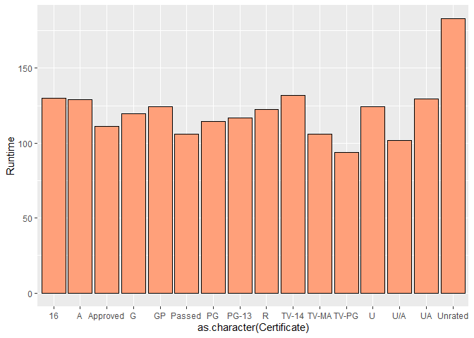

```r
imdb %>%
  drop_na(Certificate) %>%
  ggplot(aes(x = as.character(Certificate), y = Runtime)) +
    geom_bar(stat="summary", color="black", fill="lightsalmon1")
```

**Conclusion:**  
From the chart above it can be asserted that there is not a strong relationship between a movies content rating and it’s run time. The most notable trend is the notably higher run time of unrated movies.

#### Pivoting

*1. Make a column plot comparing Rotten Tomato critic and audience ratings for all the Romance movies.*

```r
ratings <- read_csv("data/Movie_Ratings.csv")
head(ratings)
```

```
## # A tibble: 6 x 6
##   Film                 Genre     `Rotten Tomatoe~ `Audience Ratin~ `Budget (millio~
##   <chr>                <chr>                <dbl>            <dbl>            <dbl>
## 1 (500) Days of Summer Comedy                  87               81                8
## 2 10,000 B.C.          Adventure                9               44              105
## 3 12 Rounds            Action                  30               52               20
## 4 127 Hours            Adventure               93               84               18
## 5 17 Again             Comedy                  55               70               20
## 6 2012                 Action                  39               63              200
## # ... with 1 more variable: Year of release <dbl>
```

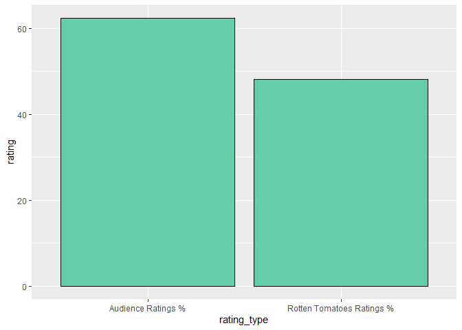

```r
ratings_long <-
  ratings %>%
  drop_na(c("Rotten Tomatoes Ratings %", "Audience Ratings %")) %>%
  pivot_longer(
    c("Rotten Tomatoes Ratings %", "Audience Ratings %"),
    names_to = "rating_type",
    values_to = "rating"
  )

ratings_long %>%
  filter(Genre=="Romance") %>%
  ggplot(aes(x=rating_type, y=rating)) +
    geom_bar(stat="summary", color="black", fill='aquamarine3')
```

*2. For each year, find the average audience rating difference between Comedy and Drama movies.*

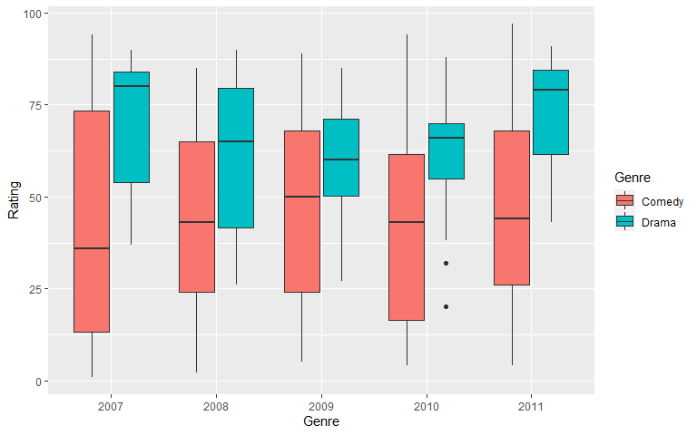

```r
ratings_comedy_drama <- ratings_long %>%
  filter(Genre==c("Comedy", "Drama"))

ratings_comedy_drama %>%
  ggplot(aes(x=as.factor(`Year of release`), y=rating, fill=Genre)) +
    geom_boxplot() +
    xlab("Genre") +
    ylab("Rating")
```

The average audience rating when compared between Comedy and Drama movies differed the most in 2007 and the least in 2009.

#### Joining

*1. How many movies appear in both datasets?*

```r
count(
  semi_join(x=ratings, y=imdb, by=c("Film"="Series_Title"))
  )
```

```
## # A tibble: 1 x 1
##       n
##   <int>
## 1    41
```

The datasets given have **41** movies in common.

*2. How many movies appear in only the imdb dataset?*

```r
count(
  anti_join(x=imdb, y=ratings, by=c("Series_Title"="Film"))
)
```

```
## # A tibble: 1 x 1
##       n
##   <int>
## 1   959
```

The IMDB dataset contains **959** unique movies that are not in the Rotten Tomatoes dataset.

*3. How many movies appear in only the Rotten Tomatoes dataset?*

```r
count(
  anti_join(x=ratings, y=imdb, by=c("Film"="Series_Title"))
)
```

```
## # A tibble: 1 x 1
##       n
##   <int>
## 1   521
```

The Rotten Tomatoes dataset contains **521** unique movies that are not in the imdb dataset.

## Joining and pivoting

*Make a plot comparing the ratings from Rotten Tomatoes Critics, Rotten Tomatoes Audience, and imdb.*

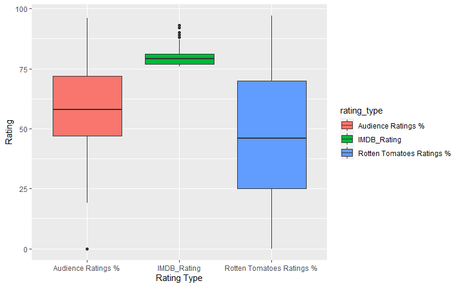

```r
# Clean data sets
imdb_clean <-
  imdb %>%
  drop_na(IMDB_Rating) %>%
  mutate(
    IMDB_Rating = IMDB_Rating * 10
  )

tomato_clean <-
  ratings %>%
  drop_na(c("Rotten Tomatoes Ratings %", "Audience Ratings %"))

all_ratings <-
  full_join(x=imdb_clean, y=tomato_clean, by=c("Series_Title"="Film")) %>%
  pivot_longer(
    c("Rotten Tomatoes Ratings %", "Audience Ratings %", "IMDB_Rating"),
    names_to = "rating_type",
    values_to = "rating"
  )

all_ratings %>%
  ggplot(aes(x=as.character(rating_type), y=rating, fill=rating_type)) +
    geom_boxplot() +
    ylab("Rating") +
    xlab("Rating Type") +
    labs("Rating Type")
```

The box-plot above provides a comparison between the distribution of ratings from IMDB, and rotten tomatoes audience and critics ratings. I scaled IMDB by 10 so it was consistent with the rotten tomatoes percentage scale out of 100%. IMDB varies the least and and has the highest mean rating. The Rotten tomato ratings are a little less forgiving and vary significantly more. The Audience ratings are generally higher than the critics ratings and vary less.